# 8.14 Time Series - Model - Forecasting

## 8.14 Time Series Demo - Air Passenger

- Fit a model using an ARIMA algorithm
- Calculate forecasts

Steps involved in time series forecasting:

```
1. Visualize the time series - check for trend, seasonality, or random patterns
2. Stationarize the series using decomposition or differencing techniques
3. Plot ACF/PACF and find (p,d,q)
4. Build an ARIMA model
5. Make predictions using final ARIMA model
```

Summary:

```
1. Perform exploratory data analysis
2. Perform decompisition of data
3. Perform stationarity check
4. Fit a model using an ARIMA algorithm
5. Calculate forecasts
```

```python
import numpy as np
import pandas as pd
from datetime import datetime as dt
from statsmodels.tsa.stattools import adfuller, acf, pacf
from statsmodels.tsa.arima_model import ARIMA
import math
import matplotlib.pyplot as plt
%matplotlib inline
from matplotlib.pylab import rcParams
rcParams['figure.figsize'] = 15,6

# import warning to disable python warning
import warnings
warnings.filterwarnings('ignore')
```

```python
# load and read the dataset
data = pd.read_csv('AirPassengers.csv')
data.head()
```

|  | Month | #Passengers |
| --- | --- | --- |
| 0 | 1949-01 | 112 |
| 1 | 1949-02 | 118 |
| 2 | 1949-03 | 132 |
| 3 | 1949-04 | 129 |
| 4 | 1949-05 | 121 |

The dataset consists of the date and monthly passenger values

```python
data['Month'].head()
```

```
0    1949-01
1    1949-02
2    1949-03
3    1949-04
4    1949-05
Name: Month, dtype: object
```

Let's display the total monthly passenger count.

Using the lambda function to filter months and add day value as 15

Set the index to months

```python
data['Month'] = data['Month'].apply(lambda x: dt(int(x[:4]), int(x[5:]), 15))
data = data.set_index('Month')
data.head()
```

| Month | #Passengers |
| --- | --- |
| 1949-01-15 | 112 |
| 1949-02-15 | 118 |
| 1949-03-15 | 132 |
| 1949-04-15 | 129 |
| 1949-05-15 | 121 |

```python
# Assigning the passengers data time series variable
ts = data['#Passengers']
```

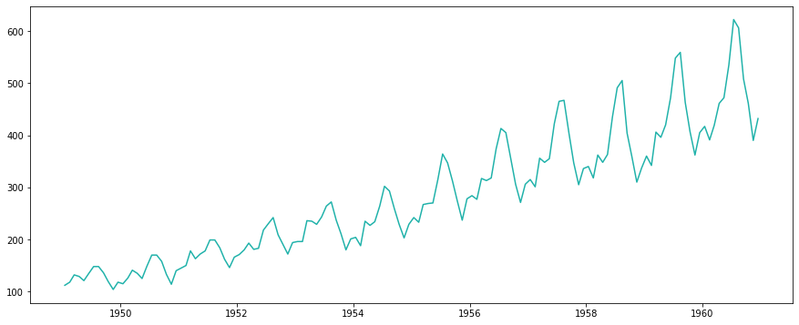

```python
# Plotting the time series
plt.plot(ts, color='lightseagreen')
```

As seen from the plot, there is an overall increase in trend with some seasonality in it. Let's transform the series with decomposition (can use log, square root, cube root etc.)

### Transform the series using log decomposition

```python
ts_log = np.log(ts)
```

### Stationarity Check

We will write a function for performing **rolling statistics** and **dickey fuller test**.

```python
def test_stationarity(timeseries):
    # determining rolling statistics
    rolmean = timeseries.rolling(window=52, center=False).mean()
    rolstd = timeseries.rolling(window=52, center=False).std()

    # plotting rolling statistics
    orig = plt.plot(timeseries, color='blue', label='Original')
    mean = plt.plot(rolmean, color='red', label='Rolling Mean')
    std = plt.plot(rolstd, color='black', label='Rolling Std')
    plt.legend(loc='best')
    plt.title('Rolling Mean & Standard Deviation')
    plt.show(block=False)

    # let's perform the dickey fuller test
    print('Results of Dickey-Fuller Test')
    dftest = adfuller(timeseries, autolag='AIC')  # initialize
    dfoutput = pd.Series(dftest[0:4], index=['Test Statistic', 'p-value', '#Lags Used', 'Number of Observations Used'])
    # initializing the critical value variable
    for key, value in dftest[4].items():
        dfoutput['Critical Value (%s)'%key] = value
    print(dfoutput)
```

Now let's apply the data to the function and see the stationarity

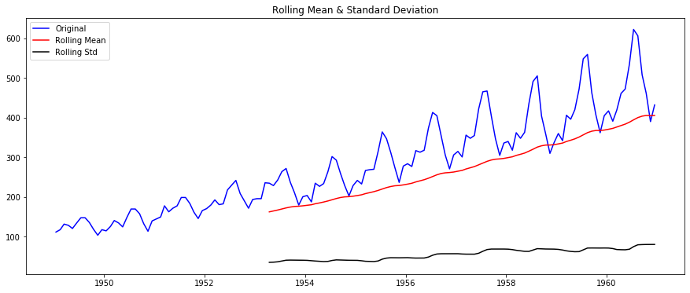

```
Results of Dickey-Fuller Test
Test Statistic                   0.815369
p-value                          0.991880
#Lags Used                      13.000000
Number of Observations Used    130.000000
Critical Value (1%)             -3.481682
Critical Value (5%)             -2.884042
Critical Value (10%)            -2.578770
dtype: float64
```

```python
test_stationarity(data['#Passengers'])
```

From the above result, we infer that the **Test Statistics** is **more/greater than** the **Critical Value** and the moving average is not constant over time. **So the null hypothesis for the Dickey-Fuller Test CANNOT be rejected**

**This shows that the time series is not stationary**

### Decomposing the data

Let's also plot the moving average

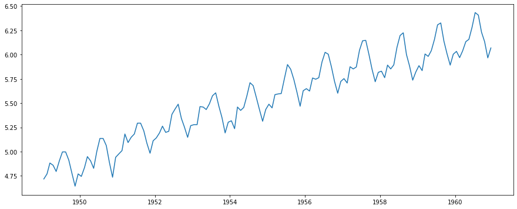

```python
plt.plot(ts_log)
```

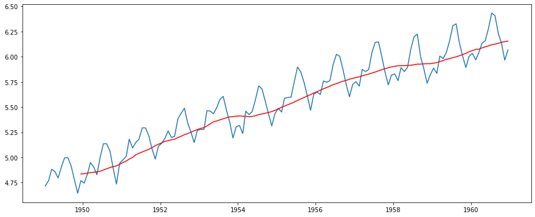

```python
# initialize the moving average variable
movingAverage = ts_log.rolling(window=12).mean()
movingSTD = ts_log.rolling(window=12).std()
plt.plot(ts_log)
plt.plot(movingAverage, color='red')
```

Let's write the code for the same

```python
# get the difference between the moving average and the actual no. of passengers
ts_log_mv_diff = ts_log - movingAverage
ts_log_mv_diff.head(12)

# drop the null values from the time series data
ts_log_mv_diff.dropna(inplace=True)
ts_log_mv_diff.head(10)
```

```
Month
1949-12-15   -0.065494
1950-01-15   -0.093449
1950-02-15   -0.007566
1950-03-15    0.099416
1950-04-15    0.052142
1950-05-15   -0.027529
1950-06-15    0.139881
1950-07-15    0.260184
1950-08-15    0.248635
1950-09-15    0.162937
Name: #Passengers, dtype: float64
```

Let's put the time series data into the function and check for stationarity

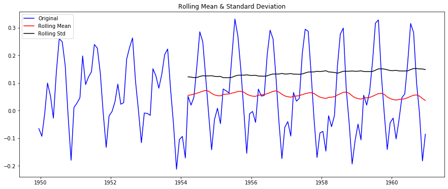

```
Results of Dickey-Fuller Test
Test Statistic                  -3.162908
p-value                          0.022235
#Lags Used                      13.000000
Number of Observations Used    119.000000
Critical Value (1%)             -3.486535
Critical Value (5%)             -2.886151
Critical Value (10%)            -2.579896
dtype: float64
```

```python
test_stationarity(ts_log_mv_diff)
```

Now that we have made the time series stationary, let's make models on the time series. We will use statistical modelling method called ARIMA to forecast the data where there are dependencies in the values.

To find out the p and q values for the model, we will use the ACF and PACF plots.

#### Plotting ACF

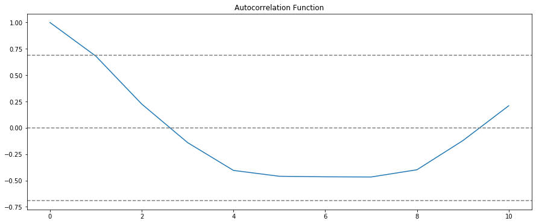

```python
# initialize the plot and plot acf
plt.plot(np.arange(0,11), acf(ts_log_mv_diff, nlags=10))
# calculating the axis
plt.axhline(y=0, linestyle='--', color='gray')
plt.axhline(y=-7.96/np.sqrt(len(ts_log_mv_diff)),linestyle='--',color='gray')
plt.axhline(y=7.96/np.sqrt(len(ts_log_mv_diff)), linestyle='--', color='gray')
plt.title('Autocorrelation Function')
plt.show()
```

The AFC curve crosses the upper confidence value when the lag value is between 0 and 1. Thus the optimal value of **q** in the ARIMA model must be 0 or 1.

#### Plotting PACF

Initialize the plot:

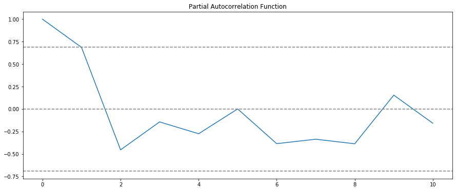

```python
plt.plot(np.arange(0,11), pacf(ts_log_mv_diff, nlags=10))
plt.axhline(y=0, linestyle='--', color='gray')
plt.axhline(y=-7.96/np.sqrt(len(ts_log_mv_diff)), linestyle='--', color='gray')
plt.axhline(y=7.96/np.sqrt(len(ts_log_mv_diff)), linestyle='--', color='gray')
plt.title('Partial Autocorrelation Function')
plt.show()
```

The PACF drops to 0 between lag values 1 and 2. Thus the optimal value of **p** in the ARIMA model is 1 or 2.

When using ARIMA, we do not explicitly differentiate because ARIMA takes care of that so we can use the ts_log (decomposed data) and leave the differencing to be done by ARIMA

```
  order = p, d, q values
```

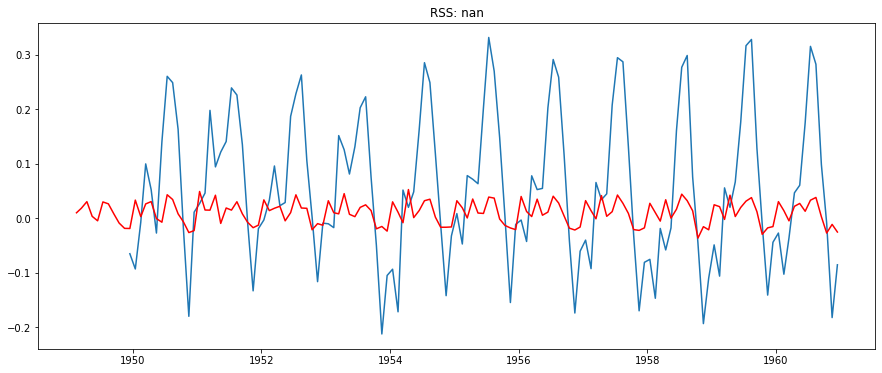

```python
# initialize the ARIMA model
model = ARIMA(ts_log, order=(1,1,0))
results_ARIMA = model.fit(disp=1)  # ARIMA model
plt.plot(ts_log_mv_diff)
plt.plot(results_ARIMA.fittedvalues, color='red')  # ARIMA model
plt.title('RSS: %.4f'%sum((results_ARIMA.fittedvalues[1:] - ts_log_mv_diff)**2))
```

#### Model prediction

The first step is to store the predicted results as a separate Series and observe it.

```python
predictions_ARIMA_diff = pd.Series(results_ARIMA.fittedvalues, copy=True)
predictions_ARIMA_diff.head()
```

```
Month
1949-02-15    0.009676
1949-03-15    0.018164
1949-04-15    0.030130
1949-05-15    0.003154
1949-06-15   -0.005039
dtype: float64
```

Notice that these start from 1949-02-15 and not the first month. This is because we took a lag by 1 and the first element doesn't have anything before to subtract from.

The way to convert the differencing to log scale is to add these differences consecutively to the base number. An easier way to do it is to first determine the cummulative sum at index and then add it to the base number.

The cummultive sum can be found as:

```python
predictions_ARIMA_diff_cumsum = predictions_ARIMA_diff.cumsum()
predictions_ARIMA_diff_cumsum.head()
```

```
Month
1949-02-15    0.009676
1949-03-15    0.027839
1949-04-15    0.057969
1949-05-15    0.061123
1949-06-15    0.056084
dtype: float64
```

And quickly do some calculations using the previous outputs to check if these are correct.

Next, add them to the base number.

Let's create a Series with all values as the base number and add the differences to it. This can be done as:

```python
predictions_ARIMA_log = pd.Series(ts_log, index=ts_log.index)
predictions_ARIMA_log = predictions_ARIMA_log.add(predictions_ARIMA_diff_cumsum, fill_value=0)
predictions_ARIMA_log.head()
```

```
Month
1949-01-15    4.718499
1949-02-15    4.780360
1949-03-15    4.910641
1949-04-15    4.917781
1949-05-15    4.856913
dtype: float64
```

```python
predictions_ARIMA_log = pd.Series(ts_log.iloc[0],index=ts_log.index)
predictions_ARIMA_log = predictions_ARIMA_log.add(predictions_ARIMA_diff_cumsum,fill_value=0)
predictions_ARIMA_log.head()
```

```
Month
1949-01-15    4.718499
1949-02-15    4.728175
1949-03-15    4.746338
1949-04-15    4.776468
1949-05-15    4.779622
dtype: float64
```

Finally we have a forecast on the original scale.

Initializing ARIMA model

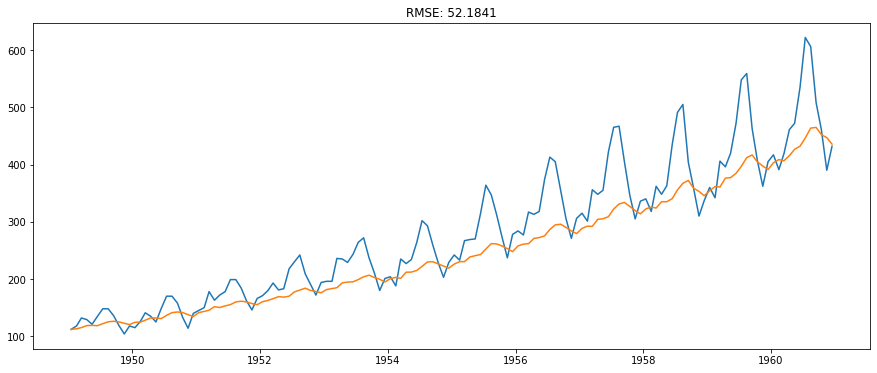

```python
predictions_ARIMA = np.exp(predictions_ARIMA_log)
plt.plot(ts)
plt.plot(predictions_ARIMA)
plt.title('RMSE: %.4f'%np.sqrt(sum((predictions_ARIMA-ts)**2)/len(ts)))
```

The orange curve is our prediction which has an RMSE of 52.1841. While our model is good at predicting the trend it fails in capturing the seasonality.